# Analisis per specie

# Pouteria torta results.

No problems detected with the QQ plots and residuals distribution.

```r
### Bombuscaro ####
# Pouteria for isotopes results ##
# other suggested model
datos_Pouteria <- data %>%
filter(data$genus == "Pouteria")

anova_model_iWUE <- aov(`iWUE (μmol/mol)` ~ N * P, data = datos_Pouteria)
anova_model_18O <- aov(`δ18O in ‰ vs DeltaSMOW` ~ N * P, data = datos_Pouteria)
anova_model_15N <- aov(`δ15N (‰ v.s.AIR)` ~ N * P, data = datos_Pouteria)
anova_model_CN <- aov(`C:N` ~ N * P, data = datos_Pouteria)


summary(anova_model_iWUE)
```

```
##             Df Sum Sq Mean Sq F value Pr(>F)
## N            1    342   342.0   1.360 0.2522
## P            1    324   323.7   1.287 0.2650
## N:P          1    908   907.8   3.610 0.0665 .
## Residuals   32   8046   251.4
## ---
## Signif. codes:  0 '***' 0.001 '**' 0.01 '*' 0.05 '.' 0.1 ' ' 1
```

```r
summary(anova_model_18O)
```

```
##             Df Sum Sq Mean Sq F value Pr(>F)
## N            1   5.33   5.329   2.956 0.0952 .
## P            1  11.37  11.369   6.306 0.0173 *
## N:P          1   0.60   0.599   0.332 0.5684
## Residuals   32  57.70   1.803
## ---
## Signif. codes:  0 '***' 0.001 '**' 0.01 '*' 0.05 '.' 0.1 ' ' 1
```

```r
summary(anova_model_15N)
```

```
##             Df Sum Sq Mean Sq F value Pr(>F)
## N            1  1.776  1.7762   2.147  0.153
## P            1  0.000  0.0001   0.000  0.992
## N:P          1  0.747  0.7465   0.903  0.349
## Residuals   32 26.468  0.8271
```

```r
summary(anova_model_CN)
```

```
##             Df Sum Sq Mean Sq F value Pr(>F)
## N            1   1.57    1.57   0.282 0.5988
## P            1  35.31   35.31   6.356 0.0169 *
## N:P          1   4.14    4.14   0.744 0.3946
## Residuals   32 177.76    5.55
## ---
## Signif. codes:  0 '***' 0.001 '**' 0.01 '*' 0.05 '.' 0.1 ' ' 1
```

```r
# Simulate residuals
sim1 <- simulateResiduals(fittedModel = anova_model_iWUE)
sim2 <- simulateResiduals(fittedModel = anova_model_18O)
sim3 <- simulateResiduals(fittedModel = anova_model_15N)
sim4 <- simulateResiduals(fittedModel = anova_model_CN)
```

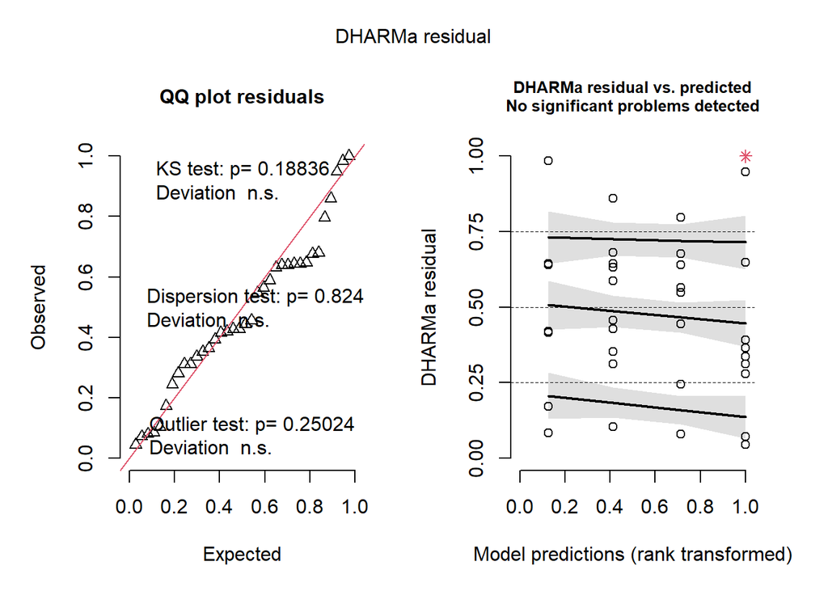

```r
# Plot 3 residual diagnostics in a grid
par(mfrow = c(1, 3))  # 1 row x 3 columns

plot(sim1)
```

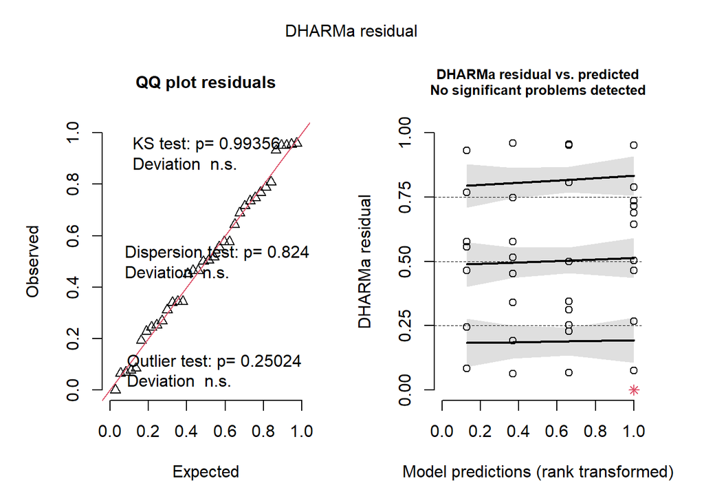

```r
plot(sim2)
```

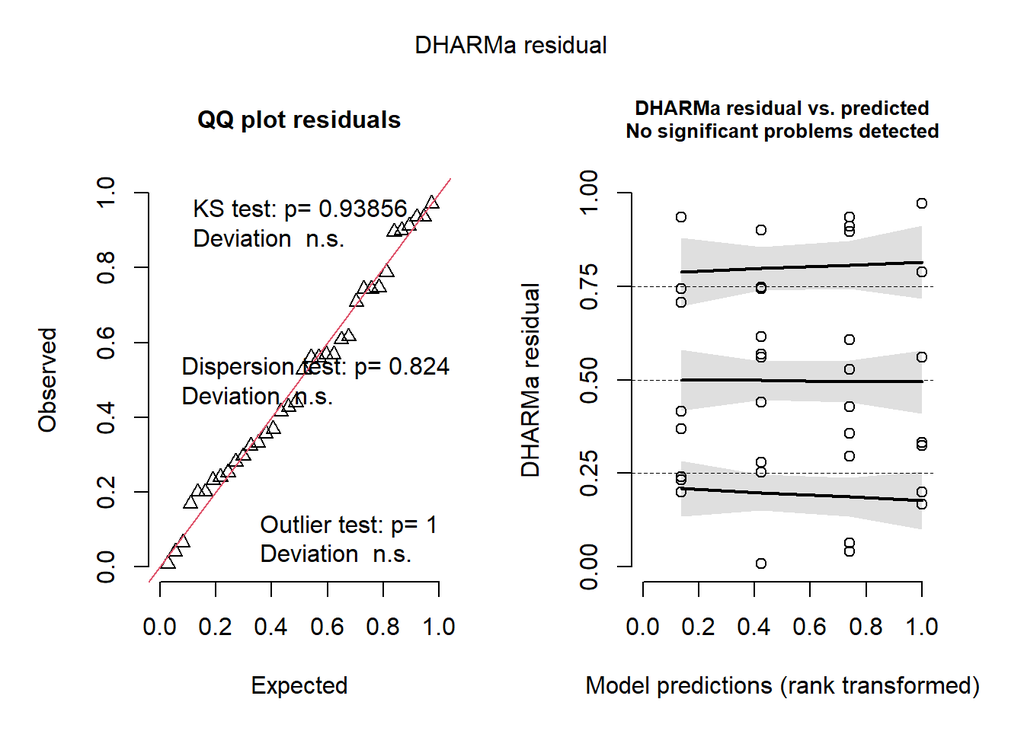

```r
plot(sim3)
```

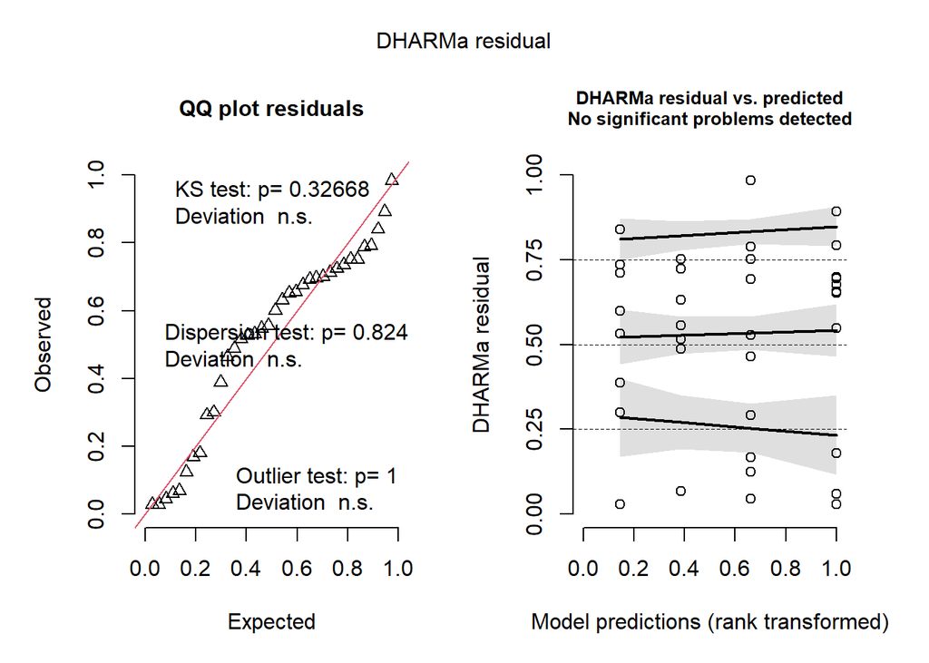

```r
plot(sim4)
```

###Pouteria: Some outliers were detected in Pouteria and may be removed for further analyses.

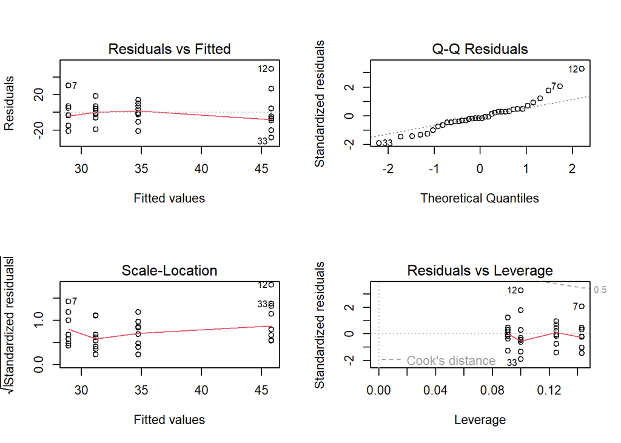

```r
par(mfrow = c(2, 2))
plot(anova_model_iWUE)
```

```r
par(mfrow = c(1, 1))
```

##Intrinsic Water Use Efficiency (iWUE): No significant differences were found between treatments overall. However, the NP treatment approached significance (p = 0.0665). iWUE increased under N addition compared to the control. Under P addition, iWUE remained higher than in the control but was lower than under N alone. When both nutrients (NP) were added simultaneously, iWUE tended to decrease relative to the single-nutrient additions.

##δ¹⁵N: No statistically significant differences were detected among treatments; however, δ¹⁵N values tended to be lower in the P treatment.

```r
#### Bombuscaro ####
### Clarisia ####
datos_Clarisia <- data %>%
filter(data$genus == "Clarisia")

anova_model_15N_cr <- aov(`δ15N (‰ v.s.AIR)` ~ N * P, data = datos_Clarisia)

anova_model_18O_cr <- aov(`δ18O in ‰ vs DeltaSMOW` ~ N * P, data = datos_Clarisia)

anova_model_iWUE_cr <- aov(`iWUE (μmol/mol)` ~ N * P, data = datos_Clarisia)
anova_model_CN_cr <- aov(`C:N` ~ N * P, data = datos_Clarisia)

summary(anova_model_iWUE_cr)
```

```
##             Df Sum Sq Mean Sq F value Pr(>F)
## N            1  343.4   343.4   3.380  0.103
## P            1  264.0   264.0   2.599  0.146
## N:P          1    1.6     1.6   0.016  0.902
## Residuals    8  812.7   101.6
```

```r
summary(anova_model_18O_cr)
```

```
##             Df Sum Sq Mean Sq F value Pr(>F)
## N            1  17.72  17.725   3.639 0.0929 .
## P            1  10.76  10.755   2.208 0.1756
## N:P          1   7.67   7.668   1.575 0.2450
## Residuals    8  38.96   4.870
## ---
## Signif. codes:  0 '***' 0.001 '**' 0.01 '*' 0.05 '.' 0.1 ' ' 1
```

```r
summary(anova_model_15N_cr)
```

```
##             Df Sum Sq Mean Sq F value Pr(>F)
## N            1  3.639   3.639   8.850 0.0177 *
## P            1  0.595   0.595   1.447 0.2634
## N:P          1  1.357   1.357   3.299 0.1069
## Residuals    8  3.290   0.411
## ---
## Signif. codes:  0 '***' 0.001 '**' 0.01 '*' 0.05 '.' 0.1 ' ' 1
```

```r
## Para la Clarisia,, no hay ninguna diferencia en iWUE. En 18O, un poco efecto de N pero hubieron muy pocas muestras para adelantar conclusiones. En N, incrementa 18O. Transpira mas.In this case N has an effect on 15N for Clarisia.Lower 15N values in the N group.
```

CAJANUMA

```r
#### Cajanuma #####
### Weinmania ####

## For Weinmania. No significant effect on iWUE, marginal effect of P. Lower iWUE in P than C. Then for 18O and 15N no difference between treatments.

datos_Weinmania <- data %>%
filter(data$genus == "Weinmania")


anova_model_15N_Wl<- aov(`δ15N (‰ v.s.AIR)` ~ N * P, data = datos_Weinmania)

anova_model_18O_Wl <- aov(`δ18O in ‰ vs DeltaSMOW` ~ N * P, data = datos_Weinmania)

anova_model_iWUE_Wl <- aov(`iWUE (μmol/mol)` ~ N * P, data = datos_Weinmania)
anova_model_CN_Wl <- aov(`C:N` ~ N * P, data = datos_Weinmania)

### Hedyosmum purpurascens ####

datos_Hp <- data %>%
filter(data$genus == "Hedyosmun")

anova_model_15N_Hp <- aov(`δ15N (‰ v.s.AIR)` ~ N * P, data = datos_Hp)

anova_model_18O_Hp <- aov(`δ18O in ‰ vs DeltaSMOW` ~ N * P, data = datos_Hp)

anova_model_iWUE_Hp <- aov(`iWUE (μmol/mol)` ~ N * P, data = datos_Hp)
anova_model_CN_Hp <- aov(`iWUE (μmol/mol)` ~ N * P, data = datos_Hp)

#Hedyosmum, no significant effect of any nutrient on these ecophysiological parameters.
```

```r
##### San Francisco #######
## Alchornea ###
datos_al <- data %>%
filter(data$name == "Alchornea lojaensis")

anova_model_15N_al <- aov(`δ15N (‰ v.s.AIR)` ~ N * P, data = datos_al)

anova_model_18O_al<- aov(`δ18O in ‰ vs DeltaSMOW` ~ N * P, data = datos_al)

anova_model_iWUE_al <- aov(`iWUE (μmol/mol)` ~ N * P, data = datos_al)
anova_model_CN_al <- aov(`C:N` ~ N * P, data = datos_al)

datos_myrcia <- data %>%
filter(data$name == "Myrcia sp nov")

anova_model_15N_m <- aov(`δ15N (‰ v.s.AIR)` ~ N * P, data = datos_myrcia)

anova_model_18O_m <- aov(`δ18O in ‰ vs DeltaSMOW` ~ N * P, data = datos_myrcia)

anova_model_iWUE_m <- aov(`iWUE (μmol/mol)` ~ N * P, data = datos_myrcia)
anova_model_CN_m <- aov(`C:N` ~ N * P, data = datos_myrcia)
```

Results: For Alchornea lojaensis, no effect on iWUE, no effect on 18O but strong effect of N on foliar 15N. 15N not absorbed similarly when P is added.

```r
mods_1000 <- list(
  "Pouteria iWUE" = anova_model_iWUE,
  "δ18O" = anova_model_18O,
  "δ15N" = anova_model_15N,
  "C:N"  = anova_model_CN,
  "Clarisia iWUE " = anova_model_iWUE_cr,
  "δ18O" = anova_model_18O_cr,
  "δ15N" = anova_model_15N_cr,
  "C:N"  = anova_model_CN_cr
)
modelsummary(
  mods_1000,
  statistic = "({statistic}, p = {p.value})",
  stars = TRUE,
  output = "markdown",
  title = "ANOVA results for *1000 species*")
```

Pouteria iWUE

δ18O

δ15N

C:N

Clarisia iWUE

δ18O

δ15N

C:N

N

(1.360, p = 0.252)

(2.956, p = 0.095)

(2.147, p = 0.153)

(0.282, p = 0.599)

(3.380, p = 0.103)

(3.639, p = 0.093)

(8.850, p = 0.018)

(8.017, p = 0.022)

P

(1.287, p = 0.265)

(6.306, p = 0.017)

(0.000, p = 0.992)

(6.356, p = 0.017)

(2.599, p = 0.146)

(2.208, p = 0.176)

(1.447, p = 0.263)

(2.345, p = 0.164)

N × P

(3.610, p = 0.066)

(0.332, p = 0.568)

(0.903, p = 0.349)

(0.744, p = 0.395)

(0.016, p = 0.902)

(1.575, p = 0.245)

(3.299, p = 0.107)

(0.363, p = 0.564)

Residuals

(, p = )

(, p = )

(, p = )

(, p = )

(, p = )

(, p = )

(, p = )

(, p = )

Num.Obs.

36

36

36

36

12

12

12

12

R2

0.164

0.231

0.087

0.187

0.428

0.481

0.630

0.573

R2 Adj.

0.085

0.159

0.001

0.111

0.214

0.287

0.491

0.413

AIC

306.9

129.1

101.1

169.7

94.6

58.2

28.5

62.4

BIC

314.8

137.1

109.0

177.6

97.1

60.6

31.0

64.9

Log.Lik.

-148.452

-59.572

-45.545

-79.826

-42.320

-24.093

-9.263

-26.213

F

2.086

3.198

1.017

2.461

1.998

2.474

4.532

3.575

RMSE

14.95

1.27

0.86

2.22

8.23

1.80

0.52

2.15

```r
mods_2000 <- list(
  "Alchornea iWUE" = anova_model_iWUE_al,
  "δ18O" = anova_model_18O_al,
  "δ15N" = anova_model_15N_al,
  "C:N"  = anova_model_CN_al,
  "Myrcia iWUE " = anova_model_iWUE_m,
  "δ18O" = anova_model_18O_m,
  "δ15N" = anova_model_15N_m,
  "C:N"  = anova_model_CN_m
)
modelsummary(
  mods_2000,
  statistic = "({statistic}, p = {p.value})",
  stars = TRUE,
  output = "markdown",
  title = "ANOVA results for *1000 species*")
```

Alchornea iWUE

δ18O

δ15N

C:N

Myrcia iWUE

δ18O

δ15N

C:N

N

(0.162, p = 0.689)

(0.009, p = 0.927)

(58.630, p = <0.001)

(8.166, p = 0.007)

(1.461, p = 0.233)

(6.635, p = 0.013)

(26.746, p = <0.001)

(10.035, p = 0.003)

P

(1.132, p = 0.293)

(0.199, p = 0.658)

(0.248, p = 0.621)

(1.278, p = 0.265)

(0.727, p = 0.398)

(2.217, p = 0.143)

(0.012, p = 0.913)

(2.677, p = 0.109)

N × P

(0.192, p = 0.664)

(0.014, p = 0.905)

(0.008, p = 0.931)

(0.173, p = 0.680)

(0.776, p = 0.383)

(0.924, p = 0.342)

(8.071, p = 0.007)

(1.839, p = 0.182)

Residuals

(, p = )

(, p = )

(, p = )

(, p = )

(, p = )

(, p = )

(, p = )

(, p = )

Num.Obs.

45

44

45

45

50

49

50

50

R2

0.035

0.006

0.590

0.190

0.061

0.178

0.431

0.240

R2 Adj.

-0.036

-0.069

0.559

0.131

-0.001

0.124

0.394

0.191

AIC

380.8

152.3

145.1

287.9

395.0

150.4

170.4

351.6

BIC

389.9

161.2

154.1

296.9

404.5

159.9

179.9

361.1

Log.Lik.

-185.418

-71.141

-67.545

-138.941

-192.493

-70.218

-80.190

-170.778

F

0.495

0.074

19.629

3.206

0.988

3.259

11.610

4.850

RMSE

14.90

1.22

1.09

5.30

11.37

1.01

1.20

7.36

```r
mods_3000 <- list(
  "Weinmania iWUE" = anova_model_iWUE_Wl,
  "δ18O" = anova_model_18O_Wl,
  "δ15N" = anova_model_15N_Wl,
  "C:N"  = anova_model_CN_Wl,
  "Hedyosmum iWUE " = anova_model_iWUE_Hp,
  "δ18O" = anova_model_18O_Hp,
  "δ15N" = anova_model_15N_Hp,
  "C:N"  = anova_model_CN_Hp
)
modelsummary(
  mods_3000,
  statistic = "({statistic}, p = {p.value})",
  stars = TRUE,
  output = "markdown",
  title = "ANOVA results for *3000 species*")
```

Weinmania iWUE

δ18O

δ15N

C:N

Hedyosmum iWUE

δ18O

δ15N

C:N

N

(0.396, p = 0.539)

(0.036, p = 0.852)

(2.468, p = 0.138)

(0.915, p = 0.355)

(2.781, p = 0.114)

(0.506, p = 0.486)

(1.248, p = 0.280)

(2.781, p = 0.114)

P

(3.386, p = 0.087)

(1.079, p = 0.317)

(1.152, p = 0.301)

(0.019, p = 0.892)

(0.184, p = 0.673)

(0.047, p = 0.832)

(1.042, p = 0.322)

(0.184, p = 0.673)

N × P

(0.108, p = 0.748)

(0.124, p = 0.730)

(0.241, p = 0.631)

(0.333, p = 0.573)

(1.663, p = 0.214)

(1.971, p = 0.178)

(0.230, p = 0.637)

(1.663, p = 0.214)

Residuals

(, p = )

(, p = )

(, p = )

(, p = )

(, p = )

(, p = )

(, p = )

(, p = )

Num.Obs.

18

18

18

18

21

21

21

21

R2

0.217

0.081

0.216

0.083

0.214

0.129

0.129

0.214

R2 Adj.

0.050

-0.116

0.048

-0.113

0.075

-0.024

-0.025

0.075

AIC

141.7

60.8

76.1

115.9

192.1

81.2

90.3

192.1

BIC

146.1

65.2

80.6

120.4

197.3

86.4

95.6

197.3

Log.Lik.

-65.830

-25.397

-33.051

-52.952

-91.040

-35.599

-40.166

-91.040

F

1.296

0.413

1.287

0.423

1.543

0.841

0.840

1.543

RMSE

9.38

0.99

1.52

4.59

18.47

1.32

1.64

18.47

```r
### Bombuscaro ####
# Pouteria for isotopes results ##
# other suggested model

# Reorder factors so "Control" is the reference

# Fit model
mod_iWUE_pt <- lmer(`iWUE (μmol/mol)` ~ N * P + (1 | Plot), data = datos_Pouteria)
mod_O18_pt <- lmer(`δ18O in ‰ vs DeltaSMOW` ~ N * P + (1 | Plot), data = datos_Pouteria)
#maybe delete outliers and see what happens. Values in P higher than 30. For the control values lower than 28.
mod_N15_pt <- lmer(`δ15N (‰ v.s.AIR)` ~ N * P + (1 | Plot), data = datos_Pouteria)
mod_CN_pt <- lmer(`δ15N (‰ v.s.AIR)` ~ N * P + (1 | Plot), data = datos_Pouteria)

mod_iWUE_cr <- lmer(`iWUE (μmol/mol)` ~ N * P + (1 | Plot), data = datos_Clarisia)
```

```
## boundary (singular) fit: see help('isSingular')
```

```r
mod_O18_cr<- lmer(`δ18O in ‰ vs DeltaSMOW` ~ N * P + (1 | Plot), data = datos_Clarisia)
mod_N15_cr<- lmer(`δ15N (‰ v.s.AIR)` ~ N * P + (1 | Plot), data = datos_Clarisia)
mod_CN_cr<- lmer(`δ15N (‰ v.s.AIR)` ~ N * P + (1 | Plot), data = datos_Clarisia)

mod_iWUE_al <- lmer(`iWUE (μmol/mol)` ~ N * P + (1 | Plot), data = datos_al)
mod_O18_al<- lmer(`δ18O in ‰ vs DeltaSMOW` ~ N * P + (1 | Plot), data = datos_al)
mod_N15_al<- lmer(`δ15N (‰ v.s.AIR)` ~ N * P + (1 | Plot), data = datos_al)
mod_CN_al<- lmer(`δ15N (‰ v.s.AIR)` ~ N * P + (1 | Plot), data = datos_al)

mod_iWUE_my <- lmer(`iWUE (μmol/mol)` ~ N * P + (1 | Plot), data = datos_myrcia)
```

```
## boundary (singular) fit: see help('isSingular')
```

```r
mod_O18_my<- lmer(`δ18O in ‰ vs DeltaSMOW` ~ N * P + (1 | Plot), data = datos_myrcia)
```

```
## boundary (singular) fit: see help('isSingular')
```

```r
mod_N15_my<- lmer(`δ15N (‰ v.s.AIR)` ~ N * P + (1 | Plot), data = datos_myrcia)
mod_CN_my<- lmer(`δ15N (‰ v.s.AIR)` ~ N * P + (1 | Plot), data = datos_myrcia)


mod_iWUE_hp <- lmer(`iWUE (μmol/mol)` ~ N * P + (1 | Plot), data = datos_Hp)
```

```
## boundary (singular) fit: see help('isSingular')
```

```r
mod_O18_hp<- lmer(`δ18O in ‰ vs DeltaSMOW` ~ N * P + (1 | Plot), data = datos_Hp)
mod_N15_hp<- lmer(`δ15N (‰ v.s.AIR)` ~ N * P + (1 | Plot), data = datos_Hp)
mod_CN_hp<- lmer(`δ15N (‰ v.s.AIR)` ~ N * P + (1 | Plot), data = datos_Hp)


mod_iWUE_wl <- lmer(`iWUE (μmol/mol)` ~ N * P + (1 | Plot), data = datos_Weinmania)
mod_O18_wl<- lmer(`δ18O in ‰ vs DeltaSMOW` ~ N * P + (1 | Plot), data = datos_Weinmania)
```

```
## boundary (singular) fit: see help('isSingular')
```

```r
mod_N15_wl<- lmer(`δ15N (‰ v.s.AIR)` ~ N * P + (1 | Plot), data = datos_Weinmania)
mod_CN_wl<- lmer(`δ15N (‰ v.s.AIR)` ~ N * P + (1 | Plot), data = datos_Weinmania)

#mod_iWUE_2 <- lmer(`iWUE (μmol/mol)` ~ Sub + (1 | Plot), data = datos_Pouteria) #HELP: Why


# exportar tabla
tab <- modelsummary(
  list(
    "Pouteria iWUE" = mod_iWUE_pt,
    "O18 pt"  = mod_O18_pt,
    "N15"  = mod_N15_pt,
        "CN"  = mod_CN_pt,

    "Clarisia iWUE" = mod_iWUE_cr,
    "O18"  = mod_O18_cr,
    "N15"  = mod_N15_cr,
    "CN"  = mod_CN_cr,

    "Alchornea iWUE" = mod_iWUE_al,
    "O18"  = mod_O18_al,
    "N15"  = mod_N15_al,
     "CN"  = mod_CN_al,

    "Myrcia iWUE" = mod_iWUE_my,
    "O18"  = mod_O18_my,
    "N15"  = mod_N15_my,
    "CN" = mod_CN_my,

    "Hedyosmum iWUE" = mod_iWUE_hp,
    "O18"  = mod_O18_hp,
    "N15"  = mod_N15_hp,
    "CN"= mod_CN_hp,

    "Weinmania iWUE" = mod_iWUE_wl,
    "O18"  = mod_O18_wl,
    "N15"  = mod_N15_wl,
    "CN"  = mod_CN_wl

  ),
  output = "data.frame",
  stars = TRUE,
  gof_map = c("nobs", "r.squared", "aic")
)

# transponer
tab_t <- as.data.frame(t(tab))

# fijar nombres de columna usando la primera fila
colnames(tab_t) <- tab_t[1, ]
tab_t <- tab_t[-1, ]  # quitar fila original de nombres

# mostrar tabla
kable(tab_t)
```

|  | estimates | estimates | estimates | estimates | estimates | estimates | estimates | estimates | estimates | estimates | gof | gof |
| --- | --- | --- | --- | --- | --- | --- | --- | --- | --- | --- | --- | --- |
| term | (Intercept) | (Intercept) | N | N | P | P | N × P | N × P | SD (Intercept Plot) | SD (Observations) | Num.Obs. | AIC |
| statistic | estimate | std.error | estimate | std.error | estimate | std.error | estimate | std.error | estimate | estimate |  |  |
| Pouteria iWUE | 26.902*** | (6.711) | 21.799* | (8.822) | 8.451 | (9.457) | -26.068+ | (12.830) | 8.459 | 14.172 | 36 | 287.1 |
| O18 pt | 30.290*** | (0.435) | -1.002 | (0.617) | -1.352* | (0.653) | 0.533 | (0.941) | 0.255 | 1.325 | 36 | 130.4 |
| N15 | 1.375** | (0.415) | 0.144 | (0.521) | -0.418 | (0.580) | 0.633 | (0.755) | 0.611 | 0.722 | 36 | 100.2 |
| CN | 1.375** | (0.415) | 0.144 | (0.521) | -0.418 | (0.580) | 0.633 | (0.755) | 0.611 | 0.722 | 36 | 100.2 |
| Clarisia iWUE | 42.596*** | (5.819) | -14.453 | (11.638) | 9.696 | (7.698) | 1.733 | (13.647) | 0.000 | 10.079 | 12 | 75.5 |
| O18 | 26.510*** | (1.316) | 4.719 | (2.632) | 2.871 | (1.891) | -3.085 | (3.202) | 1.302 | 1.870 | 12 | 50.9 |
| N15 | 0.614 | (0.421) | -0.141 | (0.842) | -0.178 | (0.649) | 1.652 | (1.060) | 0.641 | 0.348 | 12 | 29.7 |
| CN | 0.614 | (0.421) | -0.141 | (0.842) | -0.178 | (0.649) | 1.652 | (1.060) | 0.641 | 0.348 | 12 | 29.7 |
| Alchornea iWUE | 93.895*** | (6.139) | -0.226 | (8.916) | -7.207 | (8.553) | 1.671 | (12.789) | 9.457 | 13.330 | 45 | 360.2 |
| O18 | 29.712*** | (0.469) | 0.081 | (0.695) | -0.022 | (0.651) | -0.277 | (0.991) | 0.660 | 1.140 | 44 | 152.7 |
| N15 | -5.267*** | (0.378) | 2.725*** | (0.554) | 0.177 | (0.518) | 0.018 | (0.797) | 0.422 | 1.075 | 45 | 147.9 |
| CN | -5.267*** | (0.378) | 2.725*** | (0.554) | 0.177 | (0.518) | 0.018 | (0.797) | 0.422 | 1.075 | 45 | 147.9 |
| Myrcia iWUE | 77.474*** | (3.061) | 6.761 | (4.839) | 5.618 | (4.591) | -5.970 | (6.777) | 0.000 | 11.853 | 50 | 380.1 |
| O18 | 30.627*** | (0.273) | 1.122* | (0.432) | -0.188 | (0.410) | -0.587 | (0.611) | 0.000 | 1.058 | 49 | 154.8 |
| N15 | -3.555*** | (0.401) | 0.784 | (0.606) | -0.904 | (0.588) | 1.972* | (0.866) | 0.526 | 1.162 | 50 | 172.0 |
| CN | -3.555*** | (0.401) | 0.784 | (0.606) | -0.904 | (0.588) | 1.972* | (0.866) | 0.526 | 1.162 | 50 | 172.0 |
| Hedyosmum iWUE | 89.577*** | (9.182) | 5.516 | (12.432) | -5.917 | (12.022) | 24.307 | (18.849) | 0.000 | 20.531 | 21 | 169.4 |
| O18 | 26.310*** | (0.691) | 1.164 | (0.974) | 0.924 | (0.911) | -1.717 | (1.428) | 0.712 | 1.305 | 21 | 79.4 |
| N15 | -2.673** | (0.892) | 1.259 | (1.286) | 1.355 | (1.182) | -0.707 | (1.852) | 1.180 | 1.461 | 21 | 86.3 |
| CN | -2.673** | (0.892) | 1.259 | (1.286) | 1.355 | (1.182) | -0.707 | (1.852) | 1.180 | 1.461 | 21 | 86.3 |
| Weinmania iWUE | 78.657*** | (4.814) | -4.442 | (6.807) | -8.244 | (6.536) | -3.666 | (11.078) | 1.660 | 10.531 | 18 | 123.6 |
| O18 | 26.557*** | (0.503) | -0.099 | (0.711) | -0.433 | (0.681) | -0.409 | (1.162) | 0.000 | 1.125 | 18 | 60.7 |
| N15 | -4.153** | (1.028) | 1.186 | (1.453) | -0.416 | (1.442) | -1.144 | (2.229) | 1.504 | 1.187 | 18 | 70.9 |
| CN | -4.153** | (1.028) | 1.186 | (1.453) | -0.416 | (1.442) | -1.144 | (2.229) | 1.504 | 1.187 | 18 | 70.9 |